# biclustermd: An R Package for Biclustering with Missing Values

### 4.1 Analyzing the NYCflights13 biclustering

The list output of `biclustermd()` is used for rendering plots and to obtain cell information. One such visual aid is a plot of the convergence indices versus iteration, given in Figure 2. From this graphic, we can determine the rate at which convergence occurs for both row and column clusters. Moreover, this provides confirmation that our algorithm can indeed achieve good clusterings along both dimensions. Plotting of the similarity measures and SSE is done with `autoplot.biclustermd_sim()` and `autoplot.biclustermd_sse()`, methods added to `autoplot()` of [*ggplot2*](https://CRAN.R-project.org/package=ggplot2) (Wickham 2009).

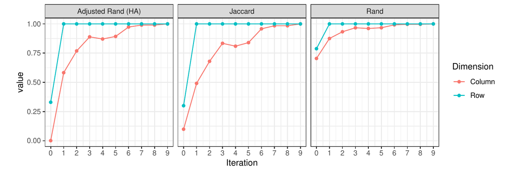

Figure 2: Plot of similarity measures for the flights biclustering

```r
> autoplot(bc$Similarities, ncol = 3) +
+   theme_bw() +
+   theme(aspect.ratio = 1) +
+   scale_x_continuous(breaks = 0:9)
```

In addition to the similarity plots, one can utilize the SSE graphic as an indication of convergence to a (local) minimum biclustering. This can be seen in Figure 3. From this we can observe the rate of decrease of the SSE as well as the relative difference between the first and final iteration. Observing closely each of the three convergence criteria suddenly decrease in value along the columns, namely from iteration three to four. The algorithm is simply (attempting to) obtain a lower SSE which may result in column shuffles which differ from iteration to iteration.

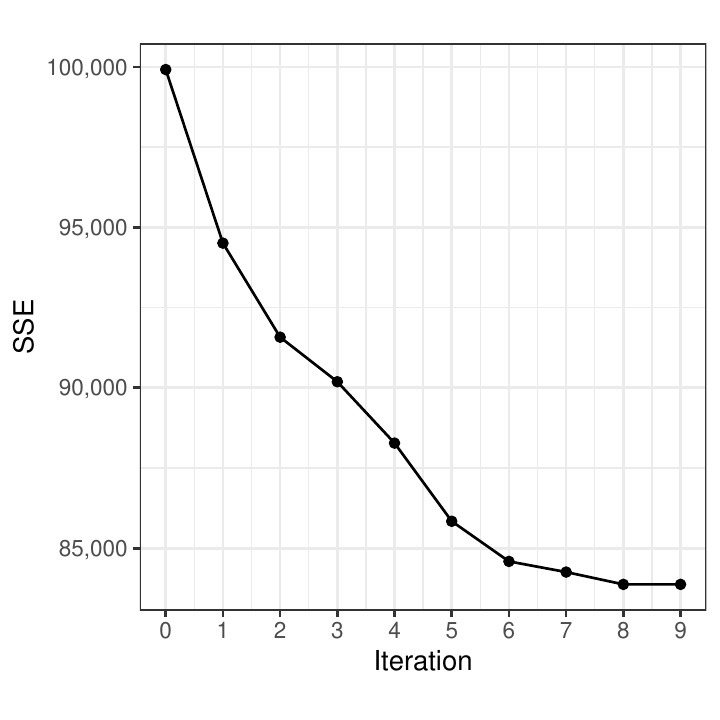

Figure 3: SSE plot of flights biclustering

```r
> autoplot(bc$SSE) +
+   theme_bw() +
+   theme(aspect.ratio = 1) +
+   scale_y_continuous(labels = comma) +
+   scale_x_continuous(breaks = 0:9)
```

Traditionally visualizations of biclustering plots are in a heat map fashion. `autoplot.biclustermd()` makes visual analysis of biclustering results easy by rendering a heat map of the biclustered data and allows for additional customization. Each of Figure 4–7 provide an example of the flexibility of this function. Recall that the algorithm uses purposeful randomness, so a replicated result may look different.

In Figure 4, we provide the default visualization without additional parameters. The white space represent cells without any observations which is directly useful for our interpretation, and the color scale is represented on the same spread as the numerical response.

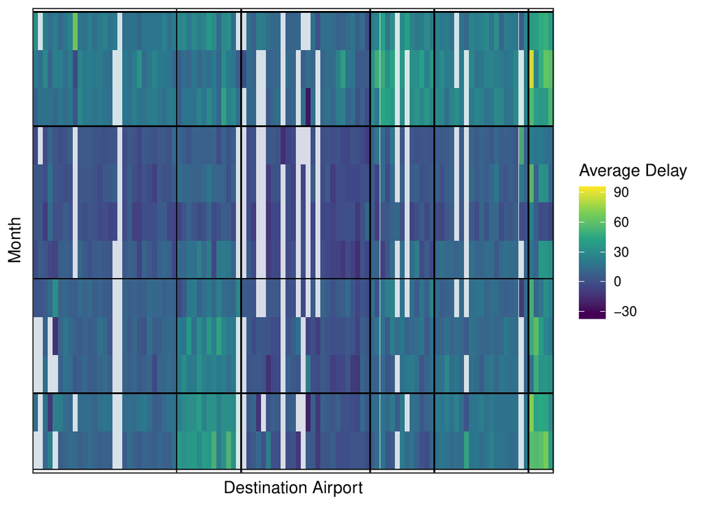

Figure 4: A heat map of the flights biclustering without transforming colors.

```r
> autoplot(bc) +
+   scale_fill_viridis_c(na.value = 'white') +
+   labs(x = "Destination Airport",
+        y = "Month",
+        fill = "Average Delay")
```

Often it may aid in interpretation to run the data through an $S$-shaped function before plotting. Two parameter arguments in `autoplot()` are `transform_colors = TRUE` and `c` where `c` is the constant to scale the data by before running it through a standard normal cumulative distribution function. See Figure 5 for an illustration. Applying this transformation, one can immediately notice the distinct dissimilarity between cells that were not clearly present in Figure 4.

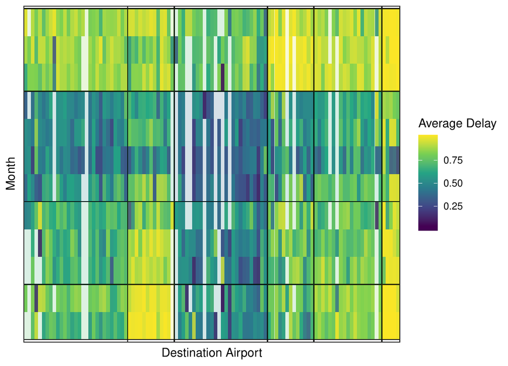

Figure 5: A heat map of the flights biclustering after transforming colors.

```r
> autoplot(bc, transform_colors = TRUE, c = 1/15) +
+   scale_fill_viridis_c(na.value = 'white') +
+   labs(x = "Destination Airport",
+        y = "Month",
+        fill = "Average Delay")
```

To further aid interpretations, we make use of `reorder_biclust` in Figure 6. This command reorders row and column clusters from increasing to decreasing mean. In our fights dataset, this may be particularly useful to determine if there is a slow shift in airport locations moving from a high to low number of delays.

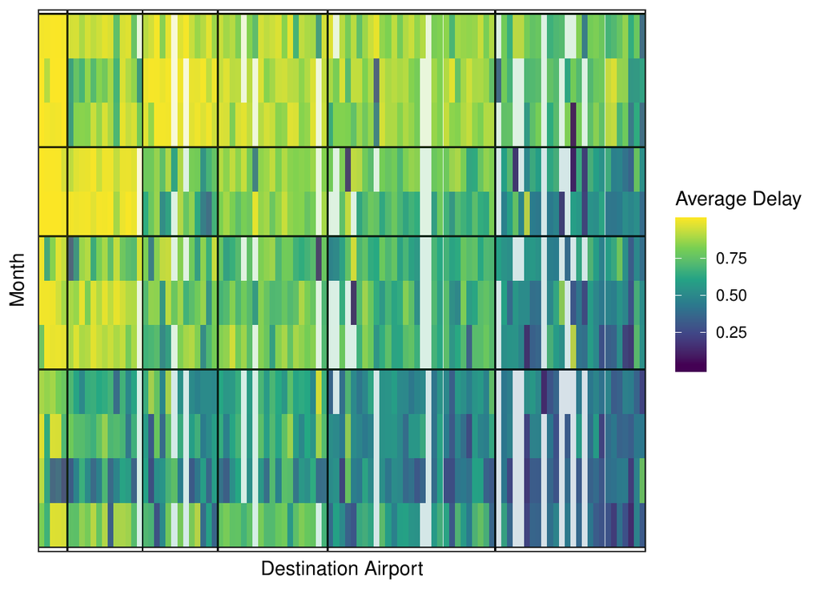

Figure 6: An ordered heat map of the flights biclustering after transforming colors.

```r
> autoplot(bc, reorder = TRUE, transform_colors = TRUE, c = 1/15) +
+   scale_fill_viridis_c(na.value = 'white') +
+   labs(x = "Destination Airport",
+        y = "Month",
+        fill = "Average Delay")
```

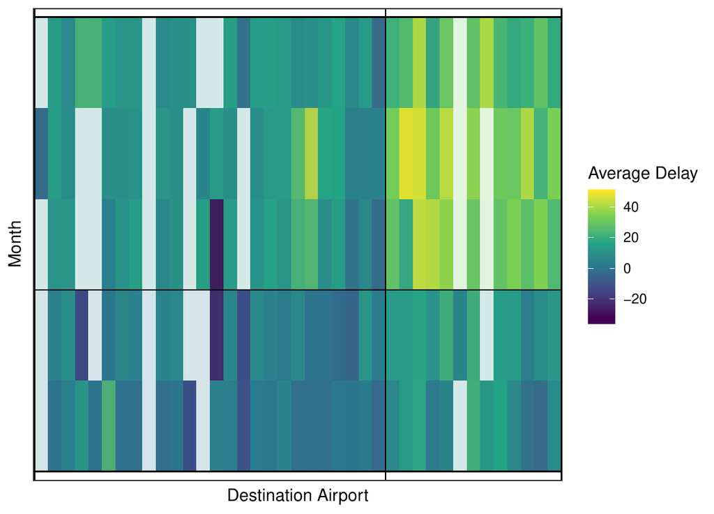

Figure 7: A zoomed in view of the heat map of the biclustering.

```r
> autoplot(bc, col_clusts = c(3, 4), row_clusts = c(1, 4)) +
+   scale_fill_viridis_c(na.value = 'white') +
+   labs(x = "Destination Airport",
+        y = "Month",
+        fill = "Average Delay")
```

There are two additional visualizations that provide insight into the quality of each cell: `mse_heatmap()` and `cell_heatmap()`. `mse_heatmap()` gives the mean squared error (MSE) of each cell. Here, MSE is defined as the mean squared difference between data values and the mean in each cell. Whereas `cell_heatmap()` provides a heatmap with the total number of observations in the given cell. Combined, these tools provide valuable insight into the homogeneity of each cell.

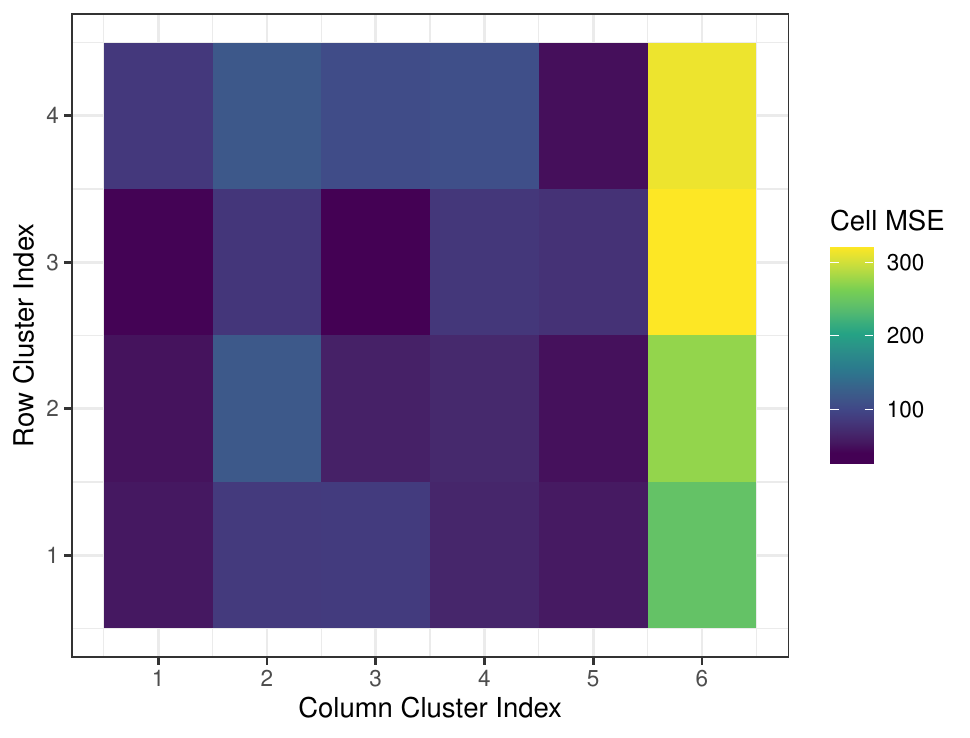

Figure 8: A heat map of cell MSEs for the flights biclustering

```r
> mse_heatmap(bc) +
+   theme_bw() +
+   scale_fill_viridis_c() +
+   labs(fill = "Cell MSE") +
+   scale_x_continuous(breaks = 1:6)
```

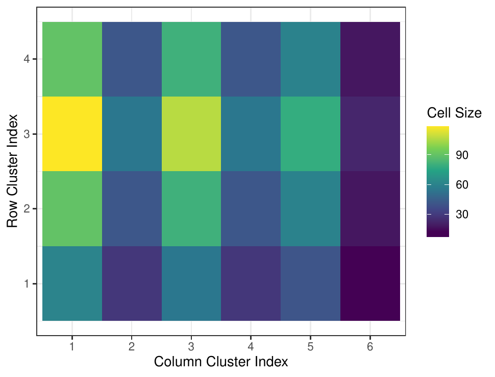

Figure 9: A heat map of cell sizes for the flights biclustering

```r
> cell_heatmap(bc) +
+   theme_bw() +
+   scale_fill_viridis_c()
```

Finally, for interpretation purposes, retrieving row or column names and their corresponding clusters is easily done using the `biclustermd` method of `row.names()` (for rows) and use of a new generic `col.names()` and its method `col.names.biclustermd()` (for columns). Two final examples are given below showing the output of each function, which have class `data.frame`.

```r
> row.names(bc) %>% head()
  row_cluster     name
1           1  January
2           1    April
3           2 February
4           2    March
5           2   August
6           3      May
```

```r
> col.names(bc) %>% head()
  col_cluster name
1           1  ABQ
2           1  ACK
3           1  AUS
4           1  AVL
5           1  BGR
6           1  BQN
```